# Metrics II - Homework 6

Farnam Taheri

2024-05-24

```r
# Load required libraries for data manipulation and analysis
library(dplyr)        # For data manipulation
library(tidyr)        # For data tidying
library(haven)        # For reading Stata data files
library(tidyverse)    # For tidy data operations
library(knitr)        # For dynamic report generation
library(stargazer)    # For regression table creation
library(ivreg)        # For instrumental variables regression
library(broom)        # For tidying regression results
library(kableExtra)   # For enhanced tables
library(ggplot2)      # For data visualization
library(plotly)       # For interactive plots
library(DT)           # For interactive tables
library(htmltools)    # For HTML formatting and content creation
library(sandwich)     # For robust standard errors
library(lmtest)       # For testing linear regression models
```

# Part I: Capital Punishment and Murder Rates

**Use the data in “MURDER” for this exercise. The variable `mrdrte` is the murder rate, that is, the number of murders per 100,000 people. The variable exec is the total number of prisoners executed for the current and prior two years; `unem` is the state unemployment rate.**

## Preliminaries

### Set the working directory

```r
# Set the working directory to the location of the data files
setwd("./Data")

# Assign the working directory to a variable for future reference
working_dir <- getwd()
```

### Load Data

This section loads the dataset required for the analysis from a Stata file.

```r
# Load the dataset for analysis (reading data from a Stata file)
murder_data <- as_tibble(read_stata(file.path(working_dir, "murder.dta")))
```

### Renaming variables for clarity

In the following code block we rename the variables in the dataset to more descriptive names. This aids in understanding the analysis and ensures that the code is self-explanatory.

```r
# Rename variables to more descriptive names
murder_data <- murder_data %>%
  rename(
    ID = id,
    State = state,
    Year = year,
    MurderRate = mrdrte,
    Executions = exec,
    UnemploymentRate = unem,
    Dummy90 = d90,
    Dummy93 = d93,
    ChangeMurderRate = cmrdrte,
    ChangeExecutions = cexec,
    ChangeUnemploymentRate = cunem,
    LaggedExecutions = cexec_1,
    LaggedUnemploymentRate = cunem_1
  )
```

## 1. States Executing Prisoners

**How many states executed at least one prisoner in 1991, 1992, or 1993? Which state had the most executions?**

This section calculates the number of states with executions and identifies the state with the most executions during the specified period (1991-1993).

```r
# Filter data for the years 1991 to 1993
executions_1991_1993 <- murder_data %>%
  filter(Year >= 91 & Year <= 93)

# Identify states with executions
states_with_executions <- executions_1991_1993 %>%
  filter(Executions > 0) %>%
  distinct(State)
num_states_executions <- nrow(states_with_executions)

# Find state with most executions
state_most_executions <- executions_1991_1993 %>%
  group_by(State) %>%
  summarise(total_exec = sum(Executions)) %>%
  arrange(desc(total_exec)) %>%
  slice(1)

# Create a formatted table with the results
knitr::kable(
  data.frame(
    Number_of_States_with_Executions = num_states_executions,
    State_with_Most_Executions = state_most_executions$State
  ),
  caption = "<center>Execution Statistics<center>",
  align = 'c', # Center align the columns
  digits = 0, # Set the number of decimal places to 0
  format = "html", # Output the table in HTML format
  table.attr = "style='width:90%;'", # Set the width of the table
  row.names = FALSE
) %>%
kable_styling(
  bootstrap_options = c("striped", "hover"), # Add Bootstrap styling options
  full_width = F # Set to false to not stretch the table to full width
) %>%
add_footnote( # Add a footnote for the data source
  "Source: Murder Accountability Project"
) %>%
scroll_box(width = "100%", height = "500px") # Add a scroll box if the table is too long
```

Execution Statistics

| Number_of_States_with_Executions | State_with_Most_Executions |
| --- | --- |
| 16 | TX |

<sup>a</sup> Source: Murder Accountability Project

### Table of Executions by State

This section creates an interactive table displaying the number of executions by state during the specified period.

```r
# Create table showing executions by state
executions_table <- executions_1991_1993 %>%
  group_by(State) %>%
  summarise(total_exec = sum(Executions)) %>%
  arrange(desc(total_exec))

# Display table with interactive features using datatable
datatable(executions_table, options = list(
              pageLength = 5,  # Set the number of rows per page
              autoWidth = TRUE,  # Automatically adjust column widths
              filter = 'top',  # Add a filter box at the top
              buttons = c('copy', 'excel', 'pdf', 'print')  # Add buttons for exporting and printing
  )
)
```

|  | State | total_exec |
| --- | --- | --- |
| 1 | TX | 34 |
| 2 | VA | 11 |
| 3 | FL | 7 |
| 4 | MO | 6 |
| 5 | AZ | 3 |
| 6 | GA | 3 |
| 7 | AL | 2 |
| 8 | AR | 2 |
| 9 | CA | 2 |
| 10 | LA | 2 |

[output cut: 41 more lines]

## 2. Pooled Regression (1990 and 1993)

**Using the two years 1990 and 1993, do a pooled regression of `mrdrte` on d93, exec, and `unem`. What do you make of the coefficient on exec?**

This section performs a pooled regression analysis of the murder rate on executions and unemployment for the years 1990 and 1993. The results are displayed using the Stargazer package.

- **Model:**

$$\text{MurderRate} = \beta_0 +
\beta_1\;\text{Dummy93} + \beta_2\;\text{Executions} +
\beta_3\;\text{UnemploymentRate} + u$$

```r
# Filter data for years 1990 and 1993
pooled_data <- murder_data %>%
  filter(Year %in% c(90, 93)) %>%  # Select only rows where Year is 1990 or 1993
  mutate(Dummy93 = ifelse(Year == 93, 1, 0))  # Create dummy variable for 1993
# Perform pooled regression analysis
pooled_model <- lm(MurderRate ~ Dummy93 + Executions + UnemploymentRate,  # Regress MurderRate on Dummy93, Executions, and UnemploymentRate
                   data = pooled_data)  # Use pooled_data as the data source

# Display regression results using Stargazer
html_output <- stargazer(pooled_model,
          type = "html",  # Set output type to plain text
          title = "<center>Pooled Regression of Murder Rate on Executions and Unemployment<center>",  # Set title
          header = FALSE,  # Remove the header
          digits = 2,  # Set the number of decimal places
          covariate.labels = c("Dummy93" = "Year 1993",  # Rename the Dummy93 variable
                               "Executions" = "Executions per 100,000",  # Rename the Executions variable
                               "UnemploymentRate" = "Unemployment Rate (%)"),  # Rename the UnemploymentRate variable
          style = "AER"
)
```

```r
# Wrap the stargazer output in a div with centering style
cat('<center>', html_output,'<center>')
```

Pooled Regression of Murder Rate on Executions and Unemployment

|  | MurderRate |
| --- | --- |
| Year 1993 | -2.07 |
|  | (2.14) |
| Executions per 100,000 | 0.13 |
|  | (0.26) |
| Unemployment Rate (%) | 2.53*** |
|  | (0.78) |
| Constant | -5.28 |
|  | (4.43) |
| Observations | 102 |
| R<sup>2</sup> | 0.10 |
| Adjusted R<sup>2</sup> | 0.07 |
| Residual Std. Error | 10.22 (df = 98) |
| F Statistic | 3.69** (df = 3; 98) |
| *Notes:* | ***Significant at the 1 percent level. |
|  | **Significant at the 5 percent level. |
|  | *Significant at the 10 percent level. |

### Result Analysis

The regression analysis indicates that:

There is no significant relationship between the murder rate and the year 1993 or the number of executions per 100,000.

However, there is a positive relationship between the murder rate and the unemployment rate. Specifically, a 1% increase in the unemployment rate is associated with a 2.53 increase in the murder rate.

The overall regression model is statistically significant, suggesting that the independent variables collectively have predictive power for the murder rate.

[output not shown]

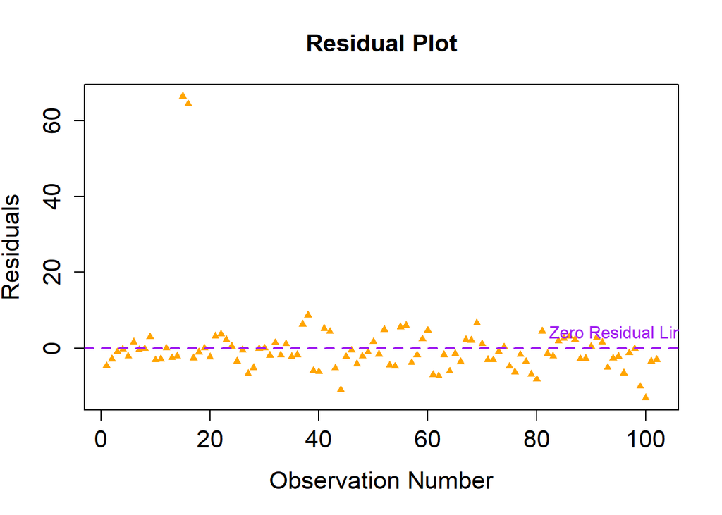

```r
# Visualize the residuals
residuals <- residuals(pooled_model)

# Create a plot with a title and labels
plot(residuals,
     main = "Residual Plot",  # Set the title
     xlab = "Observation Number",  # Set the x-axis label
     ylab = "Residuals",  # Set the y-axis label
     pch = 17,  # Set the point symbol to a bullet (•)
     col = "orange",  # Set the point color to orange
     cex = 0.8,  # Set the point size
     cex.main = 1.4,  # Set the title size
     cex.lab = 1.4,  # Set the axis label size
     cex.axis = 1.4  # Set the axis tick label size
)

# Add a horizontal line at y = 0
abline(h = 0,
       col = "purple",  # Set the line color to purple
       lty = 2,  # Set the line type to dashed
       lwd = 2  # Set the line width to 2
)

# Add a label for the horizontal line
text(x = max(par("usr")[1], par("usr")[2]) * 0.9, y = 0,
     labels = "Zero Residual Line",
     col = "purple",
     pos = 3)
```

## 3. OLS Regression with Changes

In this section, we use the first differences of the variables, which helps to remove any unobserved time-invariant effects that could bias the OLS estimates. We will discuss if capital punishment has a deterrent effect based on the sign and significance of $\beta_1$ or not

```r
# Filter the data for changes from 1990 to 1993
change_data <- murder_data %>%
filter(Year %in% c(90, 93)) %>%
mutate(Change_In_Executions = Executions - lag(Executions),
Change_In_Unemployment_Rate = UnemploymentRate - lag(UnemploymentRate),
Change_In_Murder_Rate = MurderRate - lag(MurderRate))

# Estimate the equation by OLS
change_model <- lm(Change_In_Murder_Rate ~ Change_In_Executions + Change_In_Unemployment_Rate, data = change_data)

# Report the results
html_output <- stargazer(change_model,
  type = "html", # Set output type to HTML
  title = "<center>Regression Analysis of Changes in Murder Rate, Executions, and Unemployment Rate (1990-1993)<center>", # Set title
  header = FALSE, # Remove the header
  digits = 2, # Set the number of decimal places
  covariate.labels = c("Change_In_Executions" = "Change in Executions",
                       "Change_In_Unemployment_Rate" = "Change in Unemployment Rate (%)"),
  style = "AER"
)
```

```r
# Wrap the stargazer output in a div with centering style
cat('<center>', html_output, '<center>')
```

Regression Analysis of Changes in Murder Rate, Executions, and Unemployment Rate (1990-1993)

|  | Change_In_Murder_Rate |
| --- | --- |
| Change in Executions | 0.16 |
|  | (0.24) |
| Change in Unemployment Rate (%) | 1.49** |
|  | (0.66) |
| Constant | -0.02 |
|  | (1.08) |
| Observations | 101 |
| R<sup>2</sup> | 0.06 |
| Adjusted R<sup>2</sup> | 0.04 |
| Residual Std. Error | 10.85 (df = 98) |
| F Statistic | 3.22** (df = 2; 98) |
| *Notes:* | ***Significant at the 1 percent level. |
|  | **Significant at the 5 percent level. |
|  | *Significant at the 10 percent level. |

### Key Findings

**Change in Executions**: The estimated coefficient for the change in executions is 0.16 with a standard error of 0.24, which is not statistically significant. While the coefficient’s positive value hints at a potential increase in the murder rate with more executions which is counterintuitive. To address potential endogeneity issues, such as omitted variable bias or reverse causality, we will use $\Delta exec_{-1}$ (lagged changes in executions) as an instrumental variable in the next parts.

**Change in Unemployment Rate**: The coefficient for the change in unemployment rate is significantly positive at 1.49 (with a standard error of 0.66), indicating that a 1% increase in unemployment is associated with a 1.49% increase in the murder rate. This finding underscores the importance of economic factors in influencing crime rates. The statistical significance at the 5 percent level suggests a robust relationship.

### Plot Residuals

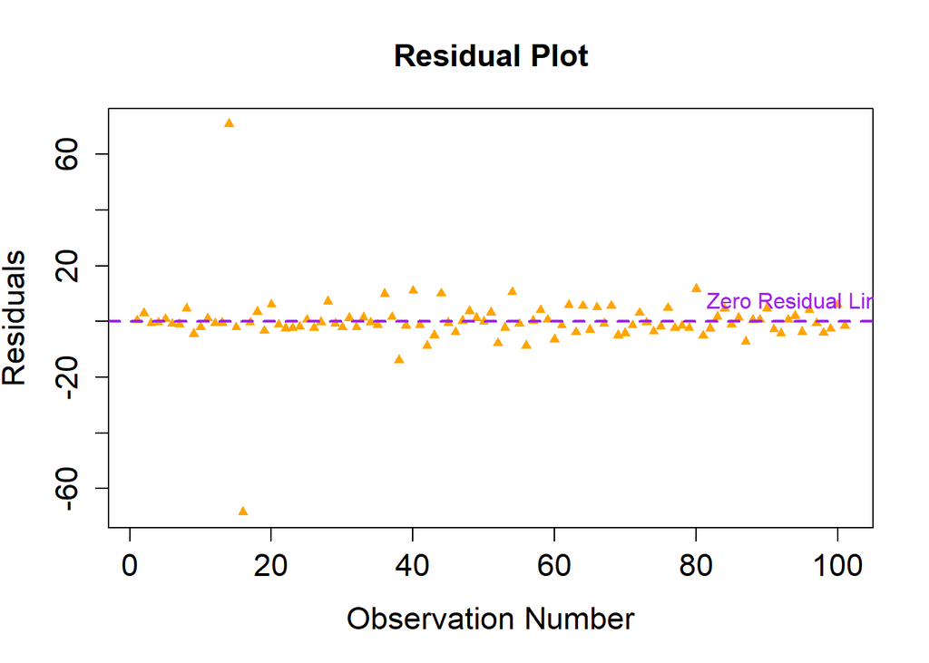

```r
# Visualize the residuals
residuals <- residuals(change_model)

# Create a plot with a title and labels
plot(residuals,
     main = "Residual Plot",  # Set the title
     xlab = "Observation Number",  # Set the x-axis label
     ylab = "Residuals",  # Set the y-axis label
     pch = 17,  # Set the point symbol to a bullet (•)
     col = "orange",  # Set the point color to orange
     cex = 0.8,  # Set the point size
     cex.main = 1.4,  # Set the title size
     cex.lab = 1.4,  # Set the axis label size
     cex.axis = 1.4  # Set the axis tick label size
)

# Add a horizontal line at y = 0
abline(h = 0,
       col = "purple",  # Set the line color to purple
       lty = 2,  # Set the line type to dashed
       lwd = 2  # Set the line width to 2
)

# Add a label for the horizontal line
text(x = max(par("usr")[1], par("usr")[2]) * 0.9, y = 0,
     labels = "Zero Residual Line",
     col = "purple",
     pos = 3)
```